# Modeling Time Series of Monthly Air Passenger Data

Sean Schilk

11/15/2025

To review concepts of a Time Series, we will load the AirPassengers dataset provided by R.

```r
data("AirPassengers")
# ?AirPassengers
# view first values
head(AirPassengers)
```

```
##      Jan Feb Mar Apr May Jun
## 1949 112 118 132 129 121 135
```

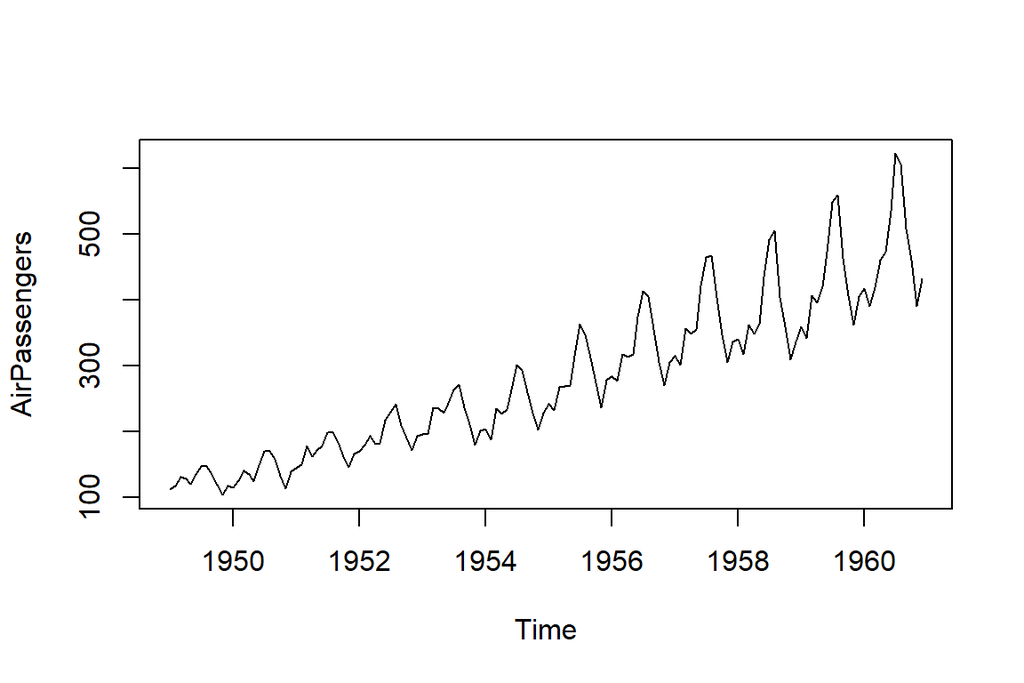

```r
# plot
plot(AirPassengers)
```

It is a monthly time series. Let’s first start by splitting the data into training and testing sets. We will hold up the most recent 10 periods to calculate the forecasting error.

```r
training = AirPassengers[1:134]
testing = AirPassengers[135:144]
##
AirPassengers.ts = ts(training, frequency = 12, start = c(1949, 1))
# freq = 12 as its monthly, start year is 1949 by 1st month (Jan)
```

Now let’s build the four baseline forecasting time series models.

```r
library(knitr)
library(forecast)
#h=10 here, as we held up 10 periods for error calculation
pred.mv = meanf(AirPassengers.ts, h=10)$mean
pred.naive = naive(AirPassengers.ts, h=10)$mean
pred.snaive = snaive(AirPassengers.ts, h=10)$mean
pred.rwf = rwf(AirPassengers.ts, h=10, drift = TRUE)$mean
###
###
pred.table = cbind( pred.mv = pred.mv,
                    pred.naive = pred.naive,
                    pred.snaive = pred.snaive,
                    pred.rwf = pred.rwf)
kable(pred.table, caption = "Forecasting Table")
```

Forecasting Table

| pred.mv | pred.naive | pred.snaive | pred.rwf |
| --- | --- | --- | --- |
| 264.6045 | 391 | 406 | 393.0977 |
| 264.6045 | 391 | 396 | 395.1955 |
| 264.6045 | 391 | 420 | 397.2932 |
| 264.6045 | 391 | 472 | 399.3910 |
| 264.6045 | 391 | 548 | 401.4887 |
| 264.6045 | 391 | 559 | 403.5865 |
| 264.6045 | 391 | 463 | 405.6842 |
| 264.6045 | 391 | 407 | 407.7820 |
| 264.6045 | 391 | 362 | 409.8797 |
| 264.6045 | 391 | 405 | 411.9774 |

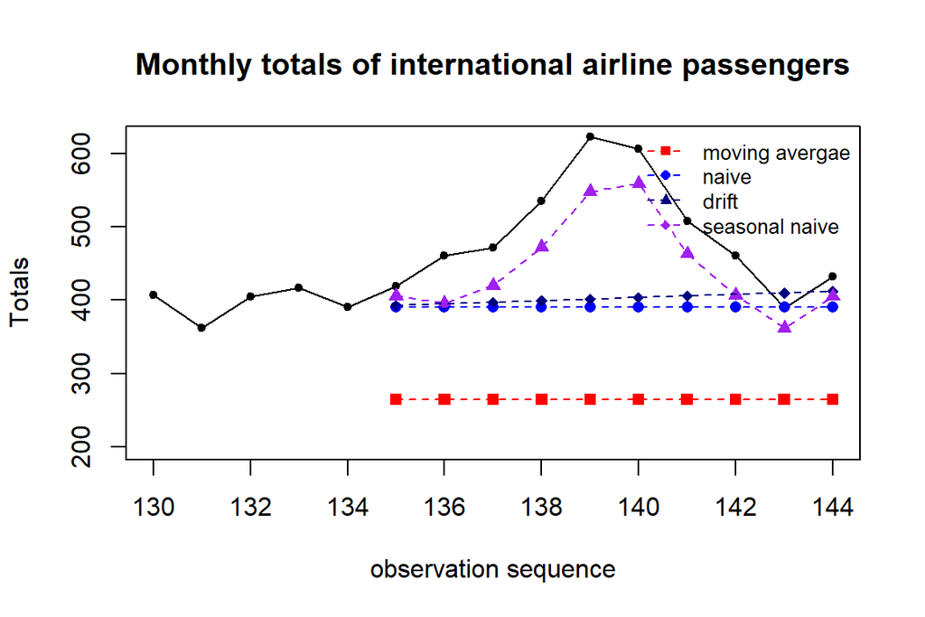

```r
plot(130:144, AirPassengers[130:144], type="l", xlim=c(130,144), ylim=c(200, 620),
     xlab = "observation sequence",
     ylab = "Totals",
     main = "Monthly totals of international airline passengers")
points(130:144, AirPassengers[130:144],pch=20)
##
points(135:144, pred.mv, pch=15, col = "red")
points(135:144, pred.naive, pch=16, col = "blue")
points(135:144, pred.rwf, pch=18, col = "navy")
points(135:144, pred.snaive, pch=17, col = "purple")
##
lines(135:144, pred.mv, lty=2, col = "red")
lines(135:144, pred.snaive, lty=2, col = "purple")
lines(135:144, pred.naive, lty=2, col = "blue")
lines(135:144, pred.rwf, lty=2, col = "navy")
##
legend("topright", c("moving avergae", "naive", "drift", "seasonal naive"),
       col=c("red", "blue", "navy", "purple"), pch=15:18, lty=rep(2,4),
       bty="n", cex = 0.8)
```

We can see seasonal naive worked the best here. Then drift and naive worked decently, with moving average working very poorly.

We will use the mean absolute prediction error (MAPE) to compare the performance of the four forecasting methods.

```r
true.value = AirPassengers[135:144]
PE.mv =  100*(true.value - pred.mv)/true.value
PE.naive =  100*(true.value - pred.naive)/true.value
PE.snaive =  100*(true.value - pred.snaive)/true.value
PE.rwf =  100*(true.value - pred.rwf)/true.value
##
MAPE.mv = mean(abs(PE.mv))
MAPE.naive = mean(abs(PE.naive))
MAPE.snaive = mean(abs(PE.snaive))
MAPE.rwf = mean(abs(PE.rwf))
##
MAPE = c(MAPE.mv, MAPE.naive, MAPE.snaive, MAPE.rwf)
## residual-based Error
e.mv = true.value - pred.mv
e.naive = true.value - pred.naive
e.snaive = true.value - pred.snaive
e.rwf = true.value - pred.rwf
## MAD
MAD.mv = sum(abs(e.mv))
MAD.naive = sum(abs(e.naive))
MAD.snaive = sum(abs(e.snaive))
MAD.rwf = sum(abs(e.rwf))
MAD = c(MAD.mv, MAD.naive, MAD.snaive, MAD.rwf)
## MSE
MSE.mv = mean((e.mv)^2)
MSE.naive = mean((e.naive)^2)
MSE.snaive = mean((e.snaive)^2)
MSE.rwf = mean((e.rwf)^2)
MSE = c(MSE.mv, MSE.naive, MSE.snaive, MSE.rwf)
##
accuracy.table = cbind(MAPE = MAPE, MAD = MAD, MSE = MSE)
row.names(accuracy.table) = c("Moving Average", "Naive", "Seasonal Naive", "Drift")
kable(accuracy.table, caption ="Overall performance of the four forecasting methods")
```

Overall performance of the four forecasting methods

|  | MAPE | MAD | MSE |
| --- | --- | --- | --- |
| Moving Average | 44.914280 | 2259.9552 | 56437.62 |
| Naive | 18.652370 | 998.0000 | 15283.80 |
| Seasonal Naive | 9.364936 | 468.0000 | 2520.60 |
| Drift | 17.190211 | 920.3835 | 13266.53 |

Seasonal Naive had the smallest MAPE, confirming it had the best performance. Naive and Drift we can also see did similarly, and moving average did poorly. The methods introduced in this module are baseline forecasting. They are all descriptive since we did not use any statistical assumptions.